# CCN Synthesis Report

28 February 2024

## Introduction

The CCN clearinghouse provides a synthesized and curated set of coastal carbon data that promotes the sharing of open data, novel analyses, and collaboration opportunities. The synthesis is created by curating and merging publicly available data through an automated script. This report documents the success or failure of the automated synthesis process, documents changes, conducts QA/QC tests, and provides visualizations and summaries of data within the clearinghouse.

**Report date: 2024/02/28-15:34**

**Synthesis status: Successful**

**Contact: Jaxine Wolfe (wolfejax@si.edu)**

## QA/QC Test Results

|  | test | result |
| --- | --- | --- |
| 1 | Core ID uniqueness | Check the following core_id(s) in the core-level data: 2B, 305, 398, 399, AL, B1, B2, B3, B4, G15, G4, G5, G9 |
| 2 | Valid core ID links in core table | No core ID in depthseries table: WBWA1109_01PU, WBWA1109_02PU, WBWA1109_03PU, WBWA1109_04PU, NSOR1209_01PU, NSOR1209_02PU, NSOR1209_03PU, NSOR1209_04PU, NBOR1409_01PU, NBOR1409_02PU, NBOR1409_03PU, Ca… |
| 3 | Valid core ID links in depthseries table | No core ID in core table: PB1, RC_U_A, RC_M_A, PR_U_A, PR_M_A, W_U_A, W_M_A, F_U_A, F_M_A |
| 4 | Test coordinate uniqueness | 1373 sets of coordinates are associated with more than one core. Check 'data/QA/duplicate_coordinates.csv' |
| 5 | Validity of column names in depthseries table | Undefined columns: ...33, ...38, th234_activity, th234_activity_se, k40_activity, k40_activity_se, ...56, ...57, date, pb210_crs_age, pb210_crs_age_sd |
| 6 | Validity of column names in cores table | Undefined columns: ...29, salinity, ...31, ecological_condition_flag, ...37, ...38, core_date, core_position_method, geomorphic_id, ...42 |
| 7 | Validity of column names in sites table | Passed |
| 8 | Validity of column names in species table | Undefined columns: ...7, ...8 |
| 9 | Validity of column names in impacts table | Undefined columns: impact_notes, ...6 |
| 10 | Validity of column names in methods table | Undefined columns: ...30, ...32, ground_or_sieved_flag, ...35, pb210_background_assumption, ...37 |

[output cut: 8 more lines]

### QAQC Result Breakdown

Cases where a core ID is present in the core-level table but not the depthseries.

```r
core_results <- anti_join(ccrcn_synthesis$cores, ccrcn_synthesis$depthseries, by="core_id") %>%
  distinct(study_id, site_id, core_id)

datatable(core_results,
          options = list(searching = TRUE,
                         paging = FALSE,
                         info = FALSE,
                         scrollY = 300,
                         scrollX = 300,
                         scrollCollapse = TRUE))
```

|  | study_id | site_id | core_id |
| --- | --- | --- | --- |
| 1 | Peck_et_al_2020 | Willapa | WBWA1109_01PU |
| 2 | Peck_et_al_2020 | Willapa | WBWA1109_02PU |
| 3 | Peck_et_al_2020 | Willapa | WBWA1109_03PU |
| 4 | Peck_et_al_2020 | Willapa | WBWA1109_04PU |
| 5 | Peck_et_al_2020 | Nestucca | NSOR1209_01PU |
| 6 | Peck_et_al_2020 | Nestucca | NSOR1209_02PU |
| 7 | Peck_et_al_2020 | Nestucca | NSOR1209_03PU |
| 8 | Peck_et_al_2020 | Nestucca | NSOR1209_04PU |
| 9 | Peck_et_al_2020 | Nehalem | NBOR1409_01PU |
| 10 | Peck_et_al_2020 | Nehalem | NBOR1409_02PU |

[output cut: 9 more lines]

Cases where a core ID is present in the depthseries table but not the core-level table.

```r
depthseries_results <- anti_join(ccrcn_synthesis$depthseries, ccrcn_synthesis$cores, by="core_id") %>%
  distinct(study_id, site_id, core_id)

datatable(depthseries_results)
```

|  | study_id | site_id | core_id |
| --- | --- | --- | --- |
| 1 | Thom_1992 | Padilla_Bay | PB1 |
| 2 | Drake_et_al_2024 | RC_U | RC_U_A |
| 3 | Drake_et_al_2024 | RC_U | RC_M_A |
| 4 | Drake_et_al_2024 | PR_U | PR_U_A |
| 5 | Drake_et_al_2024 | PR_M | PR_M_A |
| 6 | Drake_et_al_2024 | W_U | W_U_A |
| 7 | Drake_et_al_2024 | W_M | W_M_A |
| 8 | Drake_et_al_2024 | F_U | F_U_A |
| 9 | Drake_et_al_2024 | F_M | F_M_A |

Attribute Names

```r
# database_structure <- read_csv("docs/ccrcn_database_structure.csv", col_types = cols())
#
# # Extract column names for that table and subset to all columns that aren't in the controlled or uncontrolled attribute tables
# column_names <- colnames(ccrcn_synthesis$cores)
# valid_columns <- filter(database_structure, table == "cores")$attribute_name
# non_matching_columns <- subset(column_names, !(column_names %in% valid_columns))
#
# cores_uncontrolled <- ccrcn_synthesis$cores %>%
#   select(study_id, non_matching_columns)
```

## Database Overview

### Mapping

[interactive chart not shown]

**Habitat Core Counts**

| habitat | n | pct |
| --- | --- | --- |
| marsh | 6809 | 50.49 |
| mangrove | 4484 | 33.25 |
| seagrass | 940 | 6.97 |
| unvegetated | 644 | 4.78 |
| swamp | 216 | 1.60 |
| unknown | 210 | 1.56 |
| scrub/shrub | 111 | 0.82 |
| algal mat | 63 | 0.47 |
| upland | 8 | 0.06 |

**Missing Values**

```r
missing_country <- read_csv("data/QA/no_country_for_soil_cores.csv") %>%
  mutate(latitude = ifelse(is.na(latitude), "unknown", latitude),
         longitude = ifelse(is.na(longitude), "unknown", longitude))

datatable(missing_country,
          # extensions = "FixedColumns",
          options = custom_opts,
          rownames = FALSE)
```

| study_id | site_id | core_id | latitude | longitude |
| --- | --- | --- | --- | --- |
| Thom_1992 |  | SB1 | unknown | unknown |
| Thom_1992 | South_Slough | SS1 | unknown | unknown |
| Schile-Beers_and_Megonigal_2017 | Bu Tinah Shamal | Bu_Tinah_Shamal_mangrove_2 | unknown | unknown |
| Poppe_et_al_2019 | Snohomish_North_Ebey | NE_B | unknown | unknown |
| Poppe_et_al_2019 | Snohomish_Spencer_Island | SP_B | unknown | unknown |
| Drexler_et_al_2013 | Coastal_EDU_Field | Coastal_EDU_Field_2 | unknown | unknown |
| Cifuentes_et_al_2024_Nicoya | Buenaventura | Buenaventura_Camaronera_4_1 | unknown | unknown |
| Cifuentes_et_al_2024_Nicoya | Buenaventura | Buenaventura_Camaronera_4_2 | unknown | unknown |
| Cifuentes_et_al_2024_Nicoya | Buenaventura | Buenaventura_Camaronera_4_3 | unknown | unknown |
| Cifuentes_et_al_2024_Nicoya | Buenaventura | Buenaventura_Camaronera_5_1 | unknown | unknown |

[output cut: 3 more lines]

```r
missing_habitat <- read_csv("data/QA/no_habitat_cores.csv") %>%
  select_if(function(x) {!all(is.na(x))})

datatable(missing_habitat,
          # extensions = "FixedColumns",
          options = custom_opts,
          rownames = FALSE)
```

| study_id | site_id | core_id | year | month | day | core_notes | latitude | longitude | position_method | position_notes | elevation | elevation_datum | elevation_accuracy | elevation_method | salinity_class | salinity_method | vegetation_notes | inundation_class | inundation_method | core_length_flag | country | admin_division |
| --- | --- | --- | --- | --- | --- | --- | --- | --- | --- | --- | --- | --- | --- | --- | --- | --- | --- | --- | --- | --- | --- | --- |
| Schile-Beers_and_Megonigal_2017 | Al Aryam | Al_Aryam_high_sabkha_1 | 2013 | 1 | 27 |  | 24.267838 | 54.226179 | RTK |  | -31.7447 | WGS84 |  | RTK |  |  | high sabkha |  |  | core depth represents deposit depth | United Arab Emirates | Hormozgan |
| Schile-Beers_and_Megonigal_2017 | Al Aryam | Al_Aryam_high_sabkha_2 | 2013 | 1 | 27 |  | 24.268013 | 54.22627 | RTK |  | -31.7587 | WGS84 |  | RTK |  |  | high sabkha |  |  | core depth represents deposit depth | United Arab Emirates | Hormozgan |
| Schile-Beers_and_Megonigal_2017 | Al Aryam | Al_Aryam_high_sabkha_3 | 2013 | 1 | 27 |  | 24.268171 | 54.226308 | RTK |  | -31.7117 | WGS84 |  | RTK |  |  | high sabkha |  |  | core depth represents deposit depth | United Arab Emirates | Hormozgan |
| Schile-Beers_and_Megonigal_2017 | Al Aryam | Al_Aryam_high_sabkha_4 | 2013 | 1 | 27 |  | 24.268516 | 54.226443 | RTK |  | -31.8076 | WGS84 |  | RTK |  |  | high sabkha |  |  | core depth represents deposit depth | United Arab Emirates | Hormozgan |
| Schile-Beers_and_Megonigal_2017 | Thumayriyah | Thumayriyah_high_sabkha_1 | 2013 | 1 | 26 |  | 24.130454 | 53.029018 | handheld |  |  |  |  |  |  |  | high sabkha |  |  | core depth represents deposit depth | United Arab Emirates | Hormozgan |
| Schile-Beers_and_Megonigal_2017 | Thumayriyah | Thumayriyah_high_sabkha_2 | 2013 | 1 | 26 |  | 24.130103 | 53.029047 | handheld |  |  |  |  |  |  |  | high sabkha |  |  | core depth represents deposit depth | United Arab Emirates | Hormozgan |
| Schile-Beers_and_Megonigal_2017 | Thumayriyah | Thumayriyah_high_sabkha_3 | 2013 | 1 | 26 |  | 24.129726 | 53.029059 | handheld |  |  |  |  |  |  |  | high sabkha |  |  | core depth represents deposit depth | United Arab Emirates | Hormozgan |
| Schile-Beers_and_Megonigal_2017 | Al Aryam | Al_Aryam_low_sabkha_1 | 2013 | 1 | 27 |  | 24.259597 | 54.236117 | RTK |  | -31.849 | WGS84 |  | RTK |  |  | low sabkha |  |  | core depth represents deposit depth | United Arab Emirates | Hormozgan |
| Schile-Beers_and_Megonigal_2017 | Al Aryam | Al_Aryam_low_sabkha_2 | 2013 | 1 | 27 |  | 24.25977 | 54.236139 | RTK |  | -31.8763 | WGS84 |  | RTK |  |  | low sabkha |  |  | core depth represents deposit depth | United Arab Emirates | Hormozgan |
| Schile-Beers_and_Megonigal_2017 | Al Aryam | Al_Aryam_low_sabkha_3 | 2013 | 1 | 27 |  | 24.259938 | 54.23619 | RTK |  | -31.8784 | WGS84 |  | RTK |  |  | low sabkha |  |  | core depth represents deposit depth | United Arab Emirates | Hormozgan |

[output cut: 206 more lines]

### Numeric Attributes

**Summary Statistics:**

| table | attribute_name | unit | min | max | mean | median | missing_values | complete_rate |
| --- | --- | --- | --- | --- | --- | --- | --- | --- |
| methods | sediment_sieve_size | millimeter | 0.062 | 500 | 11.18344 | 1 | 166 | 0.2314814814814815 |
| methods | dry_bulk_density_temperature | celsius | 40 | 550 | 70.9085714285714 | 60 | 41 | 0.8101851851851851 |
| methods | dry_bulk_density_time | hour | 8 | 336 | 54.30434782608697 | 48 | 147 | 0.3194444444444444 |
| methods | dry_bulk_density_sample_volume | centimeterCubed | 1 | 550 | 102.858898108256 | 40.85641245993526 | 187 | 0.1342592592592593 |
| methods | loss_on_ignition_temperature | celsius | 375 | 1350 | 530.6862745098039 | 550 | 114 | 0.4722222222222222 |
| methods | loss_on_ignition_time | hour | 1 | 24 | 5.542553191489362 | 4 | 122 | 0.4351851851851852 |
| methods | loss_on_ignition_sample_volume | centimeterCubed | 4.15 | 52.5 | 23.83587777777778 | 15 | 207 | 0.04166666666666663 |
| methods | loss_on_ignition_sample_mass | gram | 1 | 10 | 3.666666666666667 | 4 | 204 | 0.05555555555555558 |
| sites | site_latitude_max | degree | -45.847435973 | 56.88 | 17.89916439942082 | 25.377885162 | 424 | 0.4094707520891365 |
| sites | site_latitude_min | degree | -45.847470977 | 56.88 | 17.87105295043366 | 25.31301 | 424 | 0.4094707520891365 |

[output cut: 43 more lines]

### Depthseries Visualization

**COMING SOON**

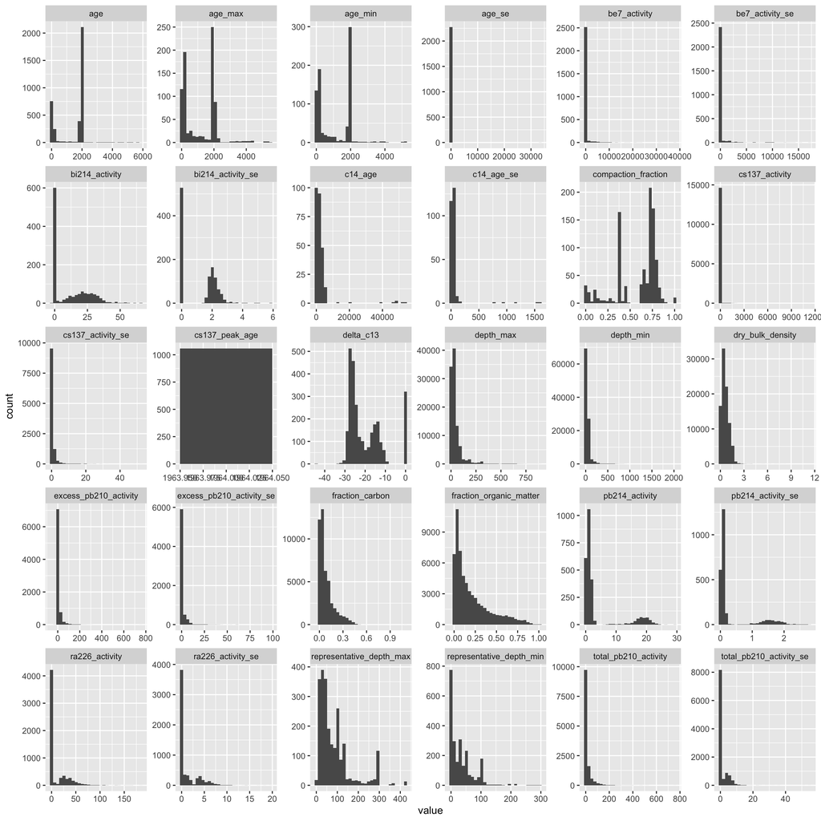

## Change Log

**COMING SOON**

## Miscellaneous

The following files were found in the derivative folders. They either do not match the approved filename structure for csvs or are another filetype

#### Unknown CSVs

```
## [1] "data/primary_studies/CIFOR/derivative_SWAMP/cifor_swamp_allometric_eq.csv, data/primary_studies/CIFOR/derivative_SWAMP/cifor_swamp_plant_plot_detail.csv, data/primary_studies/CIFOR/derivative_SWAMP/cifor_swamp_plant.csv, data/primary_studies/CIFOR/derivative_SWAMP/cifor_swamp_plot_summary.cs…
```

#### Non .csv or .bib filetypes

```
## [1] "data/primary_studies/Brown_et_al_2024/derivative/_readMe.txt, data/primary_studies/Darienzo_and_Peterson_1990/derivative/_readMe.rtf, data/primary_studies/Dontis_et_al_2020/derivative/_readMe.txt, data/primary_studies/Everhart_et_al_2020/derivative/_readMe.txt, data/primary_studies/Gillen_et…
```

#### Warnings Encountered

[output not shown]